# Project2_SupervisedLearning_SenthilvelSanthakumar

```python
import numpy as np
import pandas as pd
import matplotlib.pyplot as plt
%matplotlib inline
import seaborn as sns
from sklearn.model_selection import train_test_split
from sklearn import metrics
from sklearn.metrics import ConfusionMatrixDisplay
from sklearn.linear_model import LogisticRegression
from sklearn.neighbors import KNeighborsClassifier
from sklearn.metrics import roc_auc_score
from sklearn.metrics import classification_report
from sklearn.model_selection import GridSearchCV
from imblearn.over_sampling import SMOTE
from sklearn.svm import SVC
```

## PART A

#### Part 1. 1 a - Read all the 3 CSV files as DataFrame and store them into 3 separate variables.

```python
df1 = pd.read_csv('C:\\Users\\Sai\\Desktop\GL\\Project2_SupervisedLearning\\Normal.csv')
df2 = pd.read_csv('C:\\Users\\Sai\\Desktop\\GL\\Project2_SupervisedLearning\\Type_H.csv')
df3 = pd.read_csv('C:\\Users\\Sai\\Desktop\\GL\\Project2_SupervisedLearning\\Type_S.csv')
```

```python
df1.head()
```

|  | P_incidence | P_tilt | L_angle | S_slope | P_radius | S_Degree | Class |
| --- | --- | --- | --- | --- | --- | --- | --- |
| 0 | 38.505273 | 16.964297 | 35.112814 | 21.540976 | 127.632875 | 7.986683 | Normal |
| 1 | 54.920858 | 18.968430 | 51.601455 | 35.952428 | 125.846646 | 2.001642 | Normal |
| 2 | 44.362490 | 8.945435 | 46.902096 | 35.417055 | 129.220682 | 4.994195 | Normal |
| 3 | 48.318931 | 17.452121 | 48.000000 | 30.866809 | 128.980308 | -0.910941 | Normal |
| 4 | 45.701789 | 10.659859 | 42.577846 | 35.041929 | 130.178314 | -3.388910 | Normal |

```python
df2.head()
```

|  | P_incidence | P_tilt | L_angle | S_slope | P_radius | S_Degree | Class |
| --- | --- | --- | --- | --- | --- | --- | --- |
| 0 | 63.027817 | 22.552586 | 39.609117 | 40.475232 | 98.672917 | -0.254400 | Type_H |
| 1 | 39.056951 | 10.060991 | 25.015378 | 28.995960 | 114.405425 | 4.564259 | Type_H |
| 2 | 68.832021 | 22.218482 | 50.092194 | 46.613539 | 105.985135 | -3.530317 | Type_H |
| 3 | 69.297008 | 24.652878 | 44.311238 | 44.644130 | 101.868495 | 11.211523 | Type_H |
| 4 | 49.712859 | 9.652075 | 28.317406 | 40.060784 | 108.168725 | 7.918501 | Type_H |

```python
df3.head()
```

|  | P_incidence | P_tilt | L_angle | S_slope | P_radius | S_Degree | Class |
| --- | --- | --- | --- | --- | --- | --- | --- |
| 0 | 74.377678 | 32.053104 | 78.772013 | 42.324573 | 143.560690 | 56.125906 | Type_S |
| 1 | 89.680567 | 32.704435 | 83.130732 | 56.976132 | 129.955476 | 92.027277 | Type_S |
| 2 | 44.529051 | 9.433234 | 52.000000 | 35.095817 | 134.711772 | 29.106575 | Type_S |
| 3 | 77.690577 | 21.380645 | 64.429442 | 56.309932 | 114.818751 | 26.931841 | Type_S |
| 4 | 76.147212 | 21.936186 | 82.961502 | 54.211027 | 123.932010 | 10.431972 | Type_S |

#### Part 1.1 b - Print Shape and columns of all the 3 DataFrames

```python
print('Shape of the DataFrame 1',df1.shape)
```

```
Shape of the DataFrame 1 (100, 7)
```

```python
print('Shape of the DataFrame 2',df2.shape)
```

```
Shape of the DataFrame 2 (60, 7)
```

```python
print('Shape of the DataFrame 3',df3.shape)
```

```
Shape of the DataFrame 3 (150, 7)
```

```python
df1.info()
```

```
<class 'pandas.core.frame.DataFrame'>
RangeIndex: 100 entries, 0 to 99
Data columns (total 7 columns):
 #   Column       Non-Null Count  Dtype
---  ------       --------------  -----
 0   P_incidence  100 non-null    float64
 1   P_tilt       100 non-null    float64
 2   L_angle      100 non-null    float64
 3   S_slope      100 non-null    float64
 4   P_radius     100 non-null    float64
 5   S_Degree     100 non-null    float64
 6   Class        100 non-null    object
dtypes: float64(6), object(1)
memory usage: 5.6+ KB
```

```python
df2.info()
```

```
<class 'pandas.core.frame.DataFrame'>
RangeIndex: 60 entries, 0 to 59
Data columns (total 7 columns):
 #   Column       Non-Null Count  Dtype
---  ------       --------------  -----
 0   P_incidence  60 non-null     float64
 1   P_tilt       60 non-null     float64
 2   L_angle      60 non-null     float64
 3   S_slope      60 non-null     float64
 4   P_radius     60 non-null     float64
 5   S_Degree     60 non-null     float64
 6   Class        60 non-null     object
dtypes: float64(6), object(1)
memory usage: 3.4+ KB
```

```python
df3.info()
```

```
<class 'pandas.core.frame.DataFrame'>
RangeIndex: 150 entries, 0 to 149
Data columns (total 7 columns):
 #   Column       Non-Null Count  Dtype
---  ------       --------------  -----
 0   P_incidence  150 non-null    float64
 1   P_tilt       150 non-null    float64
 2   L_angle      150 non-null    float64
 3   S_slope      150 non-null    float64
 4   P_radius     150 non-null    float64
 5   S_Degree     150 non-null    float64
 6   Class        150 non-null    object
dtypes: float64(6), object(1)
memory usage: 8.3+ KB
```

#### Part 1.1 c - Compare Column names of all the 3 DataFrames and clearly write observations

```python
columnname1 = df1.columns
columnname2 = df2.columns
columnname3 = df3.columns
if columnname1.all() in (columnname2.all(), columnname3.all()):
    print('All the columns in the DataFrame are same')
else:
    print('All the columns in the DataFrame are not same')
```

```
All the columns in the DataFrame are same
```

##### Observations:

- All the column names in the DataFrames are same

#### Part 1.1 d - Print DataTypes of all the 3 DataFrames.

```python
df1.dtypes
```

```
P_incidence    float64
P_tilt         float64
L_angle        float64
S_slope        float64
P_radius       float64
S_Degree       float64
Class           object
dtype: object
```

```python
df2.dtypes
```

```
P_incidence    float64
P_tilt         float64
L_angle        float64
S_slope        float64
P_radius       float64
S_Degree       float64
Class           object
dtype: object
```

```python
df3.dtypes
```

```
P_incidence    float64
P_tilt         float64
L_angle        float64
S_slope        float64
P_radius       float64
S_Degree       float64
Class           object
dtype: object
```

#### Part 1.1 e - Observe and share variation in ‘Class’ feature of all the 3 DataFrames

```python
df1.groupby('Class')['Class'].count()
```

```
Class
Normal    73
Nrmal     27
Name: Class, dtype: int64
```

```python
df2.groupby('Class')['Class'].count()
```

```
Class
Type_H    37
type_h    23
Name: Class, dtype: int64
```

```python
df3.groupby('Class')['Class'].count()
```

```
Class
Type_S    133
tp_s       17
Name: Class, dtype: int64
```

#### Part 1.2 a - Unify all the variations in ‘Class’ feature for all the 3 DataFrames

```python
df1.replace(to_replace=["Normal", "Nrmal"],value="normal", inplace=True)
df1
```

|  | P_incidence | P_tilt | L_angle | S_slope | P_radius | S_Degree | Class |
| --- | --- | --- | --- | --- | --- | --- | --- |
| 0 | 38.505273 | 16.964297 | 35.112814 | 21.540976 | 127.632875 | 7.986683 | normal |
| 1 | 54.920858 | 18.968430 | 51.601455 | 35.952428 | 125.846646 | 2.001642 | normal |
| 2 | 44.362490 | 8.945435 | 46.902096 | 35.417055 | 129.220682 | 4.994195 | normal |
| 3 | 48.318931 | 17.452121 | 48.000000 | 30.866809 | 128.980308 | -0.910941 | normal |
| 4 | 45.701789 | 10.659859 | 42.577846 | 35.041929 | 130.178314 | -3.388910 | normal |
| ... | ... | ... | ... | ... | ... | ... | ... |
| 95 | 47.903565 | 13.616688 | 36.000000 | 34.286877 | 117.449062 | -4.245395 | normal |
| 96 | 53.936748 | 20.721496 | 29.220534 | 33.215251 | 114.365845 | -0.421010 | normal |
| 97 | 61.446597 | 22.694968 | 46.170347 | 38.751628 | 125.670725 | -2.707880 | normal |
| 98 | 45.252792 | 8.693157 | 41.583126 | 36.559635 | 118.545842 | 0.214750 | normal |
| 99 | 33.841641 | 5.073991 | 36.641233 | 28.767649 | 123.945244 | -0.199249 | normal |

100 rows × 7 columns

```python
df2.replace(to_replace=["Type_H"], value="type_h", inplace=True)
df2
```

|  | P_incidence | P_tilt | L_angle | S_slope | P_radius | S_Degree | Class |
| --- | --- | --- | --- | --- | --- | --- | --- |
| 0 | 63.027817 | 22.552586 | 39.609117 | 40.475232 | 98.672917 | -0.254400 | type_h |
| 1 | 39.056951 | 10.060991 | 25.015378 | 28.995960 | 114.405425 | 4.564259 | type_h |
| 2 | 68.832021 | 22.218482 | 50.092194 | 46.613539 | 105.985135 | -3.530317 | type_h |
| 3 | 69.297008 | 24.652878 | 44.311238 | 44.644130 | 101.868495 | 11.211523 | type_h |
| 4 | 49.712859 | 9.652075 | 28.317406 | 40.060784 | 108.168725 | 7.918501 | type_h |
| 5 | 40.250200 | 13.921907 | 25.124950 | 26.328293 | 130.327871 | 2.230652 | type_h |
| 6 | 53.432928 | 15.864336 | 37.165934 | 37.568592 | 120.567523 | 5.988551 | type_h |
| 7 | 45.366754 | 10.755611 | 29.038349 | 34.611142 | 117.270067 | -10.675871 | type_h |
| 8 | 43.790190 | 13.533753 | 42.690814 | 30.256437 | 125.002893 | 13.289018 | type_h |
| 9 | 36.686353 | 5.010884 | 41.948751 | 31.675469 | 84.241415 | 0.664437 | type_h |
| 10 | 49.706610 | 13.040974 | 31.334500 | 36.665635 | 108.648265 | -7.825986 | type_h |
| 11 | 31.232387 | 17.715819 | 15.500000 | 13.516568 | 120.055399 | 0.499751 | type_h |
| 12 | 48.915551 | 19.964556 | 40.263794 | 28.950995 | 119.321358 | 8.028895 | type_h |
| 13 | 53.572170 | 20.460828 | 33.100000 | 33.111342 | 110.966698 | 7.044803 | type_h |
| 14 | 57.300227 | 24.188885 | 47.000000 | 33.111342 | 116.806587 | 5.766947 | type_h |
| 15 | 44.318907 | 12.537992 | 36.098763 | 31.780915 | 124.115836 | 5.415825 | type_h |
| 16 | 63.834982 | 20.362507 | 54.552434 | 43.472475 | 112.309491 | -0.622527 | type_h |
| 17 | 31.276012 | 3.144669 | 32.562996 | 28.131342 | 129.011418 | 3.623020 | type_h |
| 18 | 38.697912 | 13.444749 | 31.000000 | 25.253163 | 123.159251 | 1.429186 | type_h |
| 19 | 41.729963 | 12.254074 | 30.122586 | 29.475889 | 116.585706 | -1.244402 | type_h |
| 20 | 43.922840 | 14.177959 | 37.832547 | 29.744881 | 134.461016 | 6.451648 | type_h |
| 21 | 54.919443 | 21.062332 | 42.200000 | 33.857110 | 125.212716 | 2.432561 | type_h |
| 22 | 63.073611 | 24.413803 | 54.000000 | 38.659808 | 106.424329 | 15.779697 | type_h |
| 23 | 45.540790 | 13.069598 | 30.298321 | 32.471192 | 117.980830 | -4.987130 | type_h |
| 24 | 36.125683 | 22.758753 | 29.000000 | 13.366931 | 115.577116 | -3.237562 | type_h |
| 25 | 54.124920 | 26.650489 | 35.329747 | 27.474432 | 121.447011 | 1.571205 | type_h |
| 26 | 26.147921 | 10.759454 | 14.000000 | 15.388468 | 125.203296 | -10.093108 | type_h |
| 27 | 43.580964 | 16.508884 | 47.000000 | 27.072080 | 109.271634 | 8.992816 | type_h |
| 28 | 44.551012 | 21.931147 | 26.785916 | 22.619865 | 111.072920 | 2.652321 | type_h |
| 29 | 66.879211 | 24.891999 | 49.278597 | 41.987212 | 113.477018 | -2.005892 | type_h |
| 30 | 50.819268 | 15.402213 | 42.528939 | 35.417055 | 112.192804 | 10.869566 | type_h |
| 31 | 46.390260 | 11.079047 | 32.136553 | 35.311213 | 98.774546 | 6.386832 | type_h |
| 32 | 44.936675 | 17.443838 | 27.780576 | 27.492837 | 117.980324 | 5.569620 | type_h |
| 33 | 38.663257 | 12.986441 | 40.000000 | 25.676816 | 124.914118 | 2.703008 | type_h |
| 34 | 59.595540 | 31.998244 | 46.560252 | 27.597296 | 119.330354 | 1.474286 | type_h |
| 35 | 31.484218 | 7.826221 | 24.284818 | 23.657997 | 113.833145 | 4.393080 | type_h |
| 36 | 32.090987 | 6.989378 | 35.998198 | 25.101609 | 132.264735 | 6.413428 | type_h |
| 37 | 35.703458 | 19.443253 | 20.700000 | 16.260205 | 137.540613 | -0.263490 | type_h |
| 38 | 55.843286 | 28.847448 | 47.690543 | 26.995838 | 123.311845 | 2.812427 | type_h |
| 39 | 52.419385 | 19.011561 | 35.872660 | 33.407825 | 116.559771 | 1.694705 | type_h |
| 40 | 35.492446 | 11.701672 | 15.590363 | 23.790774 | 106.938852 | -3.460358 | type_h |
| 41 | 46.442078 | 8.395036 | 29.037230 | 38.047043 | 115.481405 | 2.045476 | type_h |
| 42 | 53.854798 | 19.230643 | 32.779060 | 34.624155 | 121.670915 | 5.329843 | type_h |
| 43 | 66.285394 | 26.327845 | 47.500000 | 39.957549 | 121.219684 | -0.799624 | type_h |
| 44 | 56.030218 | 16.297915 | 62.275275 | 39.732303 | 114.023117 | -2.325684 | type_h |
| 45 | 50.912440 | 23.015169 | 47.000000 | 27.897271 | 117.422259 | -2.526702 | type_h |
| 46 | 48.332638 | 22.227784 | 36.181993 | 26.104854 | 117.384625 | 6.481709 | type_h |
| 47 | 41.352504 | 16.577364 | 30.706191 | 24.775141 | 113.266675 | -4.497958 | type_h |
| 48 | 40.557357 | 17.977784 | 34.000000 | 22.579573 | 121.046246 | -1.537383 | type_h |
| 49 | 41.767732 | 17.899402 | 20.030886 | 23.868330 | 118.363389 | 2.062963 | type_h |
| 50 | 55.285852 | 20.440118 | 34.000000 | 34.845733 | 115.877017 | 3.558372 | type_h |
| 51 | 74.433593 | 41.557331 | 27.700000 | 32.876262 | 107.949304 | 5.000089 | type_h |
| 52 | 50.209670 | 29.760122 | 36.104007 | 20.449548 | 128.292515 | 5.740614 | type_h |
| 53 | 30.149936 | 11.917445 | 34.000000 | 18.232491 | 112.684141 | 11.463223 | type_h |
| 54 | 41.171680 | 17.321206 | 33.469403 | 23.850474 | 116.377889 | -9.569250 | type_h |
| 55 | 47.657730 | 13.277385 | 36.679985 | 34.380345 | 98.249781 | 6.273012 | type_h |
| 56 | 43.349606 | 7.467469 | 28.065483 | 35.882137 | 112.776187 | 5.753277 | type_h |
| 57 | 46.855781 | 15.351514 | 38.000000 | 31.504267 | 116.250917 | 1.662706 | type_h |
| 58 | 43.203185 | 19.663146 | 35.000000 | 23.540039 | 124.846109 | -2.919076 | type_h |
| 59 | 48.109236 | 14.930725 | 35.564683 | 33.178512 | 124.056452 | 7.947905 | type_h |

```python
df3.replace(to_replace=["Type_S", "tp_s"], value="type_s", inplace=True)
df3
```

|  | P_incidence | P_tilt | L_angle | S_slope | P_radius | S_Degree | Class |
| --- | --- | --- | --- | --- | --- | --- | --- |
| 0 | 74.377678 | 32.053104 | 78.772013 | 42.324573 | 143.560690 | 56.125906 | type_s |
| 1 | 89.680567 | 32.704435 | 83.130732 | 56.976132 | 129.955476 | 92.027277 | type_s |
| 2 | 44.529051 | 9.433234 | 52.000000 | 35.095817 | 134.711772 | 29.106575 | type_s |
| 3 | 77.690577 | 21.380645 | 64.429442 | 56.309932 | 114.818751 | 26.931841 | type_s |
| 4 | 76.147212 | 21.936186 | 82.961502 | 54.211027 | 123.932010 | 10.431972 | type_s |
| ... | ... | ... | ... | ... | ... | ... | ... |
| 145 | 80.111572 | 33.942432 | 85.101608 | 46.169139 | 125.593624 | 100.292107 | type_s |
| 146 | 95.480229 | 46.550053 | 59.000000 | 48.930176 | 96.683903 | 77.283072 | type_s |
| 147 | 74.094731 | 18.823727 | 76.032156 | 55.271004 | 128.405731 | 73.388216 | type_s |
| 148 | 87.679087 | 20.365613 | 93.822416 | 67.313473 | 120.944829 | 76.730629 | type_s |
| 149 | 48.259920 | 16.417462 | 36.329137 | 31.842457 | 94.882336 | 28.343799 | type_s |

150 rows × 7 columns

#### Part 1.2 b - Combine all the 3 DataFrames to form a single DataFrame

```python
ndf = pd.concat([df1,df2,df3], axis =0)
ndf
```

|  | P_incidence | P_tilt | L_angle | S_slope | P_radius | S_Degree | Class |
| --- | --- | --- | --- | --- | --- | --- | --- |
| 0 | 38.505273 | 16.964297 | 35.112814 | 21.540976 | 127.632875 | 7.986683 | normal |
| 1 | 54.920858 | 18.968430 | 51.601455 | 35.952428 | 125.846646 | 2.001642 | normal |
| 2 | 44.362490 | 8.945435 | 46.902096 | 35.417055 | 129.220682 | 4.994195 | normal |
| 3 | 48.318931 | 17.452121 | 48.000000 | 30.866809 | 128.980308 | -0.910941 | normal |
| 4 | 45.701789 | 10.659859 | 42.577846 | 35.041929 | 130.178314 | -3.388910 | normal |
| ... | ... | ... | ... | ... | ... | ... | ... |
| 145 | 80.111572 | 33.942432 | 85.101608 | 46.169139 | 125.593624 | 100.292107 | type_s |
| 146 | 95.480229 | 46.550053 | 59.000000 | 48.930176 | 96.683903 | 77.283072 | type_s |
| 147 | 74.094731 | 18.823727 | 76.032156 | 55.271004 | 128.405731 | 73.388216 | type_s |
| 148 | 87.679087 | 20.365613 | 93.822416 | 67.313473 | 120.944829 | 76.730629 | type_s |
| 149 | 48.259920 | 16.417462 | 36.329137 | 31.842457 | 94.882336 | 28.343799 | type_s |

310 rows × 7 columns

#### Part 1.2 c - Print 5 random samples of this DataFrame

```python
ndf.sample(5)
```

|  | P_incidence | P_tilt | L_angle | S_slope | P_radius | S_Degree | Class |
| --- | --- | --- | --- | --- | --- | --- | --- |
| 71 | 69.781006 | 13.777465 | 58.000000 | 56.003541 | 118.930666 | 17.914560 | type_s |
| 20 | 65.611802 | 23.137919 | 62.582179 | 42.473883 | 124.128001 | -4.083298 | normal |
| 61 | 83.879941 | 23.077427 | 87.141512 | 60.802514 | 124.646072 | 80.555605 | type_s |
| 28 | 69.004913 | 13.291790 | 55.570143 | 55.713123 | 126.611621 | 10.832011 | normal |
| 34 | 59.595540 | 31.998244 | 46.560252 | 27.597296 | 119.330354 | 1.474286 | type_h |

#### Part 1.2 d - Print Feature-wise percentage of Null values

```python
ndf.isnull().sum()/len(ndf)
```

```
P_incidence    0.0
P_tilt         0.0
L_angle        0.0
S_slope        0.0
P_radius       0.0
S_Degree       0.0
Class          0.0
dtype: float64
```

#### Part 1.2 e - Check 5-point summary of the new DataFrame

```python
ndf.describe().T
```

|  | count | mean | std | min | 25% | 50% | 75% | max |
| --- | --- | --- | --- | --- | --- | --- | --- | --- |
| P_incidence | 310.0 | 60.496653 | 17.236520 | 26.147921 | 46.430294 | 58.691038 | 72.877696 | 129.834041 |
| P_tilt | 310.0 | 17.542822 | 10.008330 | -6.554948 | 10.667069 | 16.357689 | 22.120395 | 49.431864 |
| L_angle | 310.0 | 51.930930 | 18.554064 | 14.000000 | 37.000000 | 49.562398 | 63.000000 | 125.742385 |
| S_slope | 310.0 | 42.953831 | 13.423102 | 13.366931 | 33.347122 | 42.404912 | 52.695888 | 121.429566 |
| P_radius | 310.0 | 117.920655 | 13.317377 | 70.082575 | 110.709196 | 118.268178 | 125.467674 | 163.071041 |
| S_Degree | 310.0 | 26.296694 | 37.559027 | -11.058179 | 1.603727 | 11.767934 | 41.287352 | 418.543082 |

#### Part 1.3 a - Visualize a heatmap to understand correlation between all features

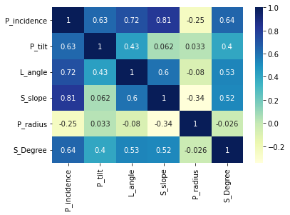

```python
dataplot = sns.heatmap(ndf.corr(), cmap="YlGnBu", annot=True)
plt.show()
```

#### Part 1.3 b - Share insights on correlation

- **P_incidence** and **S_slope** have the strong correlation of **0.81**
- **P_radius** and **S_slope** have high negative correlation of **-0.34**

#### Part 1.3 c - Visualize a pairplot with 3 classes distinguished by colors and share insights

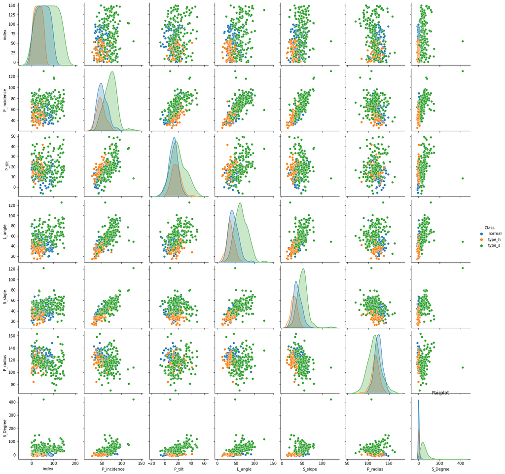

```python
ndf.reset_index(level=0, inplace=True)
sns.pairplot(ndf, vars=ndf.columns[0:7], hue="Class")
plt.title('Pairplot')
plt.show()
```

#### Part 1.3 d - Visualize a jointplot for ‘P_incidence’ and ‘S_slope’ and share insights

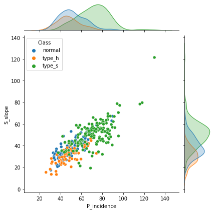

```python
sns.jointplot(data = ndf, x='P_incidence', y='S_slope', hue='Class',
              kind='scatter', height=6, ratio=5, space=0.2)
plt.show()
```

#### Insights

- High correlation between **P_insidence** and **S_slope**
- There is a **type_s** outlier

#### Part 1.3 e - Visualize a boxplot to check distribution of the features and share insights.

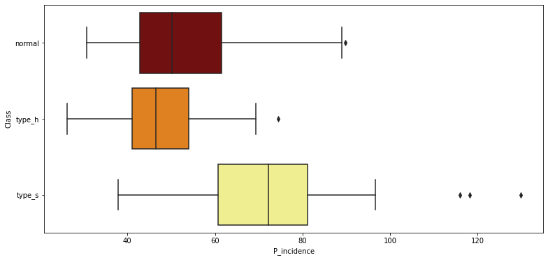

```python
plt.figure(figsize = (12.8 , 6))
ax = sns.boxplot(x = 'P_incidence', y = 'Class', palette = 'afmhot', data = ndf)
plt.show()
```

#### Insights

- Outliers are more in **type_s** class
- **normal** and **type_h** are positively skewed
- **type_s** is negatively skewed

#### Part 1.4 a - Split data into X and Y.

```python
x = ndf.drop('Class',axis=1)
y = ndf['Class']
print(x)
print(y)
```

```
     index  P_incidence     P_tilt    L_angle    S_slope    P_radius  \
0        0    38.505273  16.964297  35.112814  21.540976  127.632875
1        1    54.920858  18.968430  51.601455  35.952428  125.846646
2        2    44.362490   8.945435  46.902096  35.417055  129.220682
3        3    48.318931  17.452121  48.000000  30.866809  128.980308
4        4    45.701789  10.659859  42.577846  35.041929  130.178314
..     ...          ...        ...        ...        ...         ...
305    145    80.111572  33.942432  85.101608  46.169139  125.593624
306    146    95.480229  46.550053  59.000000  48.930176   96.683903
307    147    74.094731  18.823727  76.032156  55.271004  128.405731
308    148    87.679087  20.365613  93.822416  67.313473  120.944829
309    149    48.259920  16.417462  36.329137  31.842457   94.882336

       S_Degree
0      7.986683
```

[output cut: 24 more lines]

#### Part 1.4 b - Split data into train and test with 80:20 proportion

```python
x_train, x_test, y_train, y_test = train_test_split(x, y, test_size=0.2, random_state=1)
```

```python
print("{0:0.2f}% data is in training set".format((len(x_train)/len(ndf.index)) * 100))
print("{0:0.2f}% data is in test set".format((len(x_test)/len(ndf.index)) * 100))
```

```
80.00% data is in training set
20.00% data is in test set
```

#### Part 1.4 c - Train a Supervised Learning Classification base model using KNN classifier

```python
KNN = KNeighborsClassifier(n_neighbors = 5, weights = 'distance')
KNN.fit(x_train, y_train)
predicted_labels = KNN.predict(x_test)
print(KNN.score(x_train, y_train))
print(KNN.score(x_test, y_test))
```

```
1.0
0.8548387096774194
```

#### Part 1.4 d - Print all the possible performance metrics for both train and test data

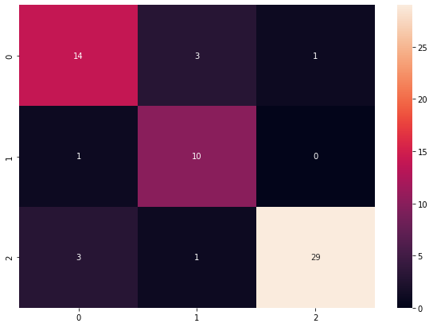

```python
from sklearn.metrics import plot_confusion_matrix
conf_matr = metrics.confusion_matrix(y_test, predicted_labels)
df_conf_matr = pd.DataFrame(conf_matr)
plt.figure(figsize = (10,7))
sns.heatmap(df_conf_matr, annot=True, fmt = 'g')
plt.show()
```

```python
print('classification report:\n', classification_report(y_test, predicted_labels))
```

```
classification report:
               precision    recall  f1-score   support

      normal       0.78      0.78      0.78        18
      type_h       0.71      0.91      0.80        11
      type_s       0.97      0.88      0.92        33

    accuracy                           0.85        62
   macro avg       0.82      0.86      0.83        62
weighted avg       0.87      0.85      0.86        62
```

#### Part 1.5 a - Experiment with various parameters to improve performance of the base model

```python
leaf_size1 = list(range(1,50))
n_neighbors1 = list(range(1,30))
p1=[1,2]
hyperparameters1 = dict(leaf_size=leaf_size1, n_neighbors=n_neighbors1, p=p1)
knn_1 = KNeighborsClassifier()
clf = GridSearchCV(knn_1, param_grid = hyperparameters1, cv=10)
best_knn_model = clf.fit(x_train,y_train)
best_knn_model_predictions = best_knn_model.predict(x_test)
print('Best leaf_size:', best_knn_model.best_estimator_.get_params()['leaf_size'])
print('Best p:', best_knn_model.best_estimator_.get_params()['p'])
print('Best n_neighbors:', best_knn_model.best_estimator_.get_params()['n_neighbors'])
```

```
Best leaf_size: 1
Best p: 2
Best n_neighbors: 20
```

```python
print('classification report:\n', classification_report(y_test, best_knn_model_predictions))
```

```
classification report:
               precision    recall  f1-score   support

      normal       0.64      0.78      0.70        18
      type_h       0.67      0.73      0.70        11
      type_s       0.93      0.79      0.85        33

    accuracy                           0.77        62
   macro avg       0.74      0.76      0.75        62
weighted avg       0.80      0.77      0.78        62
```

```python
best_knn_model.best_score_
```

```
0.8873333333333331
```

```python
best_knn_model.best_params_
```

```
{'leaf_size': 1, 'n_neighbors': 20, 'p': 2}
```

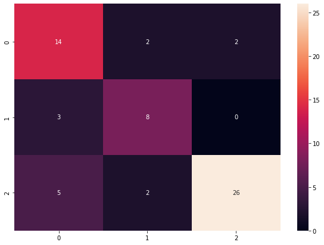

```python
conf_matr_tune = metrics.confusion_matrix(y_test, best_knn_model_predictions)
df_conf_matr_tune = pd.DataFrame(conf_matr_tune)
plt.figure(figsize = (10,7))
sns.heatmap(df_conf_matr_tune, annot=True, fmt = 'g')
plt.show()
```

## PART B

#### Part 2.1 a - Read both the Datasets ‘Data1’ and ‘Data 2’ as DataFrame and store them into two separate variables

```python
bank1 = pd.read_csv('C:\\Users\\Sai\\Desktop\\GL\\Project2_SupervisedLearning\\Data1.csv')
bank1.head()
```

|  | ID | Age | CustomerSince | HighestSpend | ZipCode | HiddenScore | MonthlyAverageSpend | Level |
| --- | --- | --- | --- | --- | --- | --- | --- | --- |
| 0 | 1 | 25 | 1 | 49 | 91107 | 4 | 1.6 | 1 |
| 1 | 2 | 45 | 19 | 34 | 90089 | 3 | 1.5 | 1 |
| 2 | 3 | 39 | 15 | 11 | 94720 | 1 | 1.0 | 1 |
| 3 | 4 | 35 | 9 | 100 | 94112 | 1 | 2.7 | 2 |
| 4 | 5 | 35 | 8 | 45 | 91330 | 4 | 1.0 | 2 |

```python
bank2 = pd.read_csv('C:\\Users\\Sai\\Desktop\\GL\\Project2_SupervisedLearning\\Data2.csv')
bank2.head()
```

|  | ID | Mortgage | Security | FixedDepositAccount | InternetBanking | CreditCard | LoanOnCard |
| --- | --- | --- | --- | --- | --- | --- | --- |
| 0 | 1 | 0 | 1 | 0 | 0 | 0 | NaN |
| 1 | 2 | 0 | 1 | 0 | 0 | 0 | NaN |
| 2 | 3 | 0 | 0 | 0 | 0 | 0 | NaN |
| 3 | 4 | 0 | 0 | 0 | 0 | 0 | NaN |
| 4 | 5 | 0 | 0 | 0 | 0 | 1 | NaN |

#### Part 2.1 b - Print shape and Column Names and DataTypes of both the Dataframes.

```python
print('Shape of the Data1', bank1.shape)
bank1.info()
```

```
Shape of the Data1 (5000, 8)
<class 'pandas.core.frame.DataFrame'>
RangeIndex: 5000 entries, 0 to 4999
Data columns (total 8 columns):
 #   Column               Non-Null Count  Dtype
---  ------               --------------  -----
 0   ID                   5000 non-null   int64
 1   Age                  5000 non-null   int64
 2   CustomerSince        5000 non-null   int64
 3   HighestSpend         5000 non-null   int64
 4   ZipCode              5000 non-null   int64
 5   HiddenScore          5000 non-null   int64
 6   MonthlyAverageSpend  5000 non-null   float64
 7   Level                5000 non-null   int64
dtypes: float64(1), int64(7)
memory usage: 312.6 KB
```

```python
print('Shape of the Data2', bank2.shape)
bank2.info()
```

```
Shape of the Data2 (5000, 7)
<class 'pandas.core.frame.DataFrame'>
RangeIndex: 5000 entries, 0 to 4999
Data columns (total 7 columns):
 #   Column               Non-Null Count  Dtype
---  ------               --------------  -----
 0   ID                   5000 non-null   int64
 1   Mortgage             5000 non-null   int64
 2   Security             5000 non-null   int64
 3   FixedDepositAccount  5000 non-null   int64
 4   InternetBanking      5000 non-null   int64
 5   CreditCard           5000 non-null   int64
 6   LoanOnCard           4980 non-null   float64
dtypes: float64(1), int64(6)
memory usage: 273.6 KB
```

#### Part 2.1 c -Merge both the Dataframes on ‘ID’ feature to form a single DataFrame

```python
bank = pd.merge(bank1,bank2, on = 'ID')
bank
```

|  | ID | Age | CustomerSince | HighestSpend | ZipCode | HiddenScore | MonthlyAverageSpend | Level | Mortgage | Security | FixedDepositAccount | InternetBanking | CreditCard | LoanOnCard |
| --- | --- | --- | --- | --- | --- | --- | --- | --- | --- | --- | --- | --- | --- | --- |
| 0 | 1 | 25 | 1 | 49 | 91107 | 4 | 1.6 | 1 | 0 | 1 | 0 | 0 | 0 | NaN |
| 1 | 2 | 45 | 19 | 34 | 90089 | 3 | 1.5 | 1 | 0 | 1 | 0 | 0 | 0 | NaN |
| 2 | 3 | 39 | 15 | 11 | 94720 | 1 | 1.0 | 1 | 0 | 0 | 0 | 0 | 0 | NaN |
| 3 | 4 | 35 | 9 | 100 | 94112 | 1 | 2.7 | 2 | 0 | 0 | 0 | 0 | 0 | NaN |
| 4 | 5 | 35 | 8 | 45 | 91330 | 4 | 1.0 | 2 | 0 | 0 | 0 | 0 | 1 | NaN |
| ... | ... | ... | ... | ... | ... | ... | ... | ... | ... | ... | ... | ... | ... | ... |
| 4995 | 4996 | 29 | 3 | 40 | 92697 | 1 | 1.9 | 3 | 0 | 0 | 0 | 1 | 0 | 0.0 |
| 4996 | 4997 | 30 | 4 | 15 | 92037 | 4 | 0.4 | 1 | 85 | 0 | 0 | 1 | 0 | 0.0 |
| 4997 | 4998 | 63 | 39 | 24 | 93023 | 2 | 0.3 | 3 | 0 | 0 | 0 | 0 | 0 | 0.0 |
| 4998 | 4999 | 65 | 40 | 49 | 90034 | 3 | 0.5 | 2 | 0 | 0 | 0 | 1 | 0 | 0.0 |
| 4999 | 5000 | 28 | 4 | 83 | 92612 | 3 | 0.8 | 1 | 0 | 0 | 0 | 1 | 1 | 0.0 |

5000 rows × 14 columns

#### Part 2.1 d -Change Datatype of below features to ‘Object'

```python
convert_datatype = {'CreditCard':object,'InternetBanking':object, 'FixedDepositAccount':object, 'Security':object,
                    'Level':object, 'HiddenScore':object }
bank = bank.astype(convert_datatype)
bank.dtypes
```

```
ID                       int64
Age                      int64
CustomerSince            int64
HighestSpend             int64
ZipCode                  int64
HiddenScore             object
MonthlyAverageSpend    float64
Level                   object
Mortgage                 int64
Security                object
FixedDepositAccount     object
InternetBanking         object
CreditCard              object
LoanOnCard             float64
dtype: object
```

#### Part 2.2 a -Visualize distribution of Target variable ‘LoanOnCard’ and clearly share insights

```python
display(bank['LoanOnCard'].value_counts(), bank['LoanOnCard'].value_counts(normalize = True)*100)
```

```
0.0    4500
1.0     480
Name: LoanOnCard, dtype: int64
```

```
0.0    90.361446
1.0     9.638554
Name: LoanOnCard, dtype: float64
```

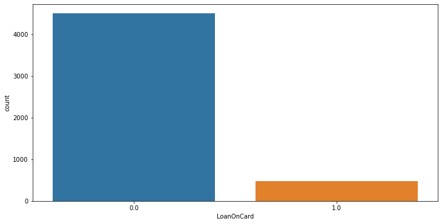

```python
fig = plt.figure(figsize = (12,6))
sns.countplot(bank['LoanOnCard'])
plt.show()
```

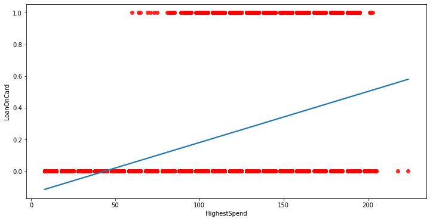

```python
fig = plt.figure(figsize = (12,6))
sns.regplot(bank.HighestSpend, bank.LoanOnCard, order=1, ci=None, scatter_kws={'color':'r'})
plt.show()
```

```python
print(display(bank['CreditCard'].value_counts(), bank['CreditCard'].value_counts(normalize = True)*100))
print(display(bank['LoanOnCard'].value_counts(), bank['LoanOnCard'].value_counts(normalize = True)*100))
```

```
0    3530
1    1470
Name: CreditCard, dtype: int64
```

```
0    70.6
1    29.4
Name: CreditCard, dtype: float64
```

```
None
```

```
0.0    4500
1.0     480
Name: LoanOnCard, dtype: int64
```

```
0.0    90.361446
1.0     9.638554
Name: LoanOnCard, dtype: float64
```

```
None
```

### Insights

#### Part 2.2 b -Check the percentage of missing values and impute if required

```python
percent_missing = bank.isnull().sum() * 100 / len(bank)
missing_value_bank = pd.DataFrame({'column_name': bank.columns,'percent_missing': percent_missing})
print(missing_value_bank)
```

```
                             column_name  percent_missing
ID                                    ID              0.0
Age                                  Age              0.0
CustomerSince              CustomerSince              0.0
HighestSpend                HighestSpend              0.0
ZipCode                          ZipCode              0.0
HiddenScore                  HiddenScore              0.0
MonthlyAverageSpend  MonthlyAverageSpend              0.0
Level                              Level              0.0
Mortgage                        Mortgage              0.0
Security                        Security              0.0
FixedDepositAccount  FixedDepositAccount              0.0
InternetBanking          InternetBanking              0.0
CreditCard                    CreditCard              0.0
LoanOnCard                    LoanOnCard              0.4
```

```python
bank['LoanOnCard'].fillna(0, inplace=True)
print(bank)
```

```
        ID  Age  CustomerSince  HighestSpend  ZipCode HiddenScore  \
0        1   25              1            49    91107           4
1        2   45             19            34    90089           3
2        3   39             15            11    94720           1
3        4   35              9           100    94112           1
4        5   35              8            45    91330           4
...    ...  ...            ...           ...      ...         ...
4995  4996   29              3            40    92697           1
4996  4997   30              4            15    92037           4
4997  4998   63             39            24    93023           2
4998  4999   65             40            49    90034           3
4999  5000   28              4            83    92612           3

      MonthlyAverageSpend Level  Mortgage Security FixedDepositAccount  \
0                     1.6     1         0        1                   0
```

[output cut: 25 more lines]

#### Part 2.2 c -Check for unexpectedvalues in each categorical variable and impute with best suitable value.

```python
bank['CustomerSince'] = bank['CustomerSince'].abs()  #Converted the negative values positive values
missing_values = ["?", "a", "-"]
banknew = bank.replace(missing_values, np.nan)
banknew = banknew.apply(lambda x: x.fillna(0),axis=0)
banknew.isnull().sum()
```

```
ID                     0
Age                    0
CustomerSince          0
HighestSpend           0
ZipCode                0
HiddenScore            0
MonthlyAverageSpend    0
Level                  0
Mortgage               0
Security               0
FixedDepositAccount    0
InternetBanking        0
CreditCard             0
LoanOnCard             0
dtype: int64
```

```python
columns=banknew.columns
for column in columns:
    banknew[column]=banknew[column].astype(str)
banknew.info()
```

```
<class 'pandas.core.frame.DataFrame'>
Int64Index: 5000 entries, 0 to 4999
Data columns (total 14 columns):
 #   Column               Non-Null Count  Dtype
---  ------               --------------  -----
 0   ID                   5000 non-null   object
 1   Age                  5000 non-null   object
 2   CustomerSince        5000 non-null   object
 3   HighestSpend         5000 non-null   object
 4   ZipCode              5000 non-null   object
 5   HiddenScore          5000 non-null   object
 6   MonthlyAverageSpend  5000 non-null   object
 7   Level                5000 non-null   object
 8   Mortgage             5000 non-null   object
 9   Security             5000 non-null   object
 10  FixedDepositAccount  5000 non-null   object
 11  InternetBanking      5000 non-null   object
 12  CreditCard           5000 non-null   object
 13  LoanOnCard           5000 non-null   object
dtypes: object(14)
memory usage: 585.9+ KB
```

##### * Changed (-) values in the CustomerSince column with the absolute value and There is no more unexpected values in the catagorical variables.

#### Part 2.3 a-Split data into X and Y

```python
y1 = banknew["LoanOnCard"]
x1 = banknew.drop(["ID","ZipCode", "LoanOnCard"], axis=1)
```

#### Part 2.3 b -Split data into train and test. Keep 25% data reserved for testing

```python
x1_train, x1_test, y1_train, y1_test = train_test_split(x1,y1, test_size = 0.25, random_state = 1)
print("{0:0.2f}% data is in training set".format((len(x1_train)/len(banknew.index)) * 100))
print("{0:0.2f}% data is in test set".format((len(x1_test)/len(banknew.index)) * 100))
print(display(y1_train.value_counts(), y1_train.value_counts(normalize = True)*100))
```

```
75.00% data is in training set
25.00% data is in test set
```

```
0.0    3399
1.0     351
Name: LoanOnCard, dtype: int64
```

```
0.0    90.64
1.0     9.36
Name: LoanOnCard, dtype: float64
```

```
None
```

#### Part 2.3 c -Train a Supervised Learning Classification base model -Logistic Regression

```python
log_model = LogisticRegression(solver="liblinear")
log_model.fit(x1_train, y1_train)
log_y1_predict = log_model.predict(x1_test)
```

```python
log_model_score_test = log_model.score(x1_test, y1_test)
log_model_score_train = log_model.score(x1_train, y1_train)
print(log_model_score_test)
print(log_model_score_train)
```

```
0.9456
0.9509333333333333
```

#### Part 2.3 d -Print evaluation metrics for the model and clearly share insights.

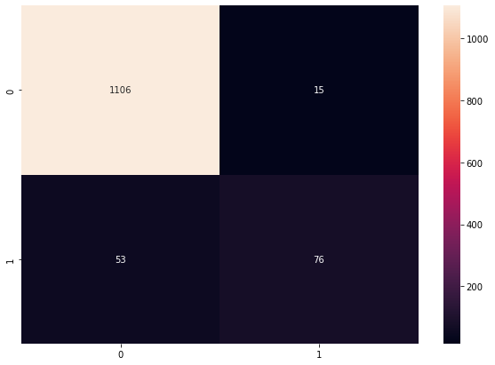

```python
from sklearn.metrics import plot_confusion_matrix
conf_mat = metrics.confusion_matrix(y1_test, log_y1_predict)
df_conf_mat = pd.DataFrame(conf_mat)
plt.figure(figsize = (10,7))
sns.heatmap(df_conf_mat, annot=True, fmt = 'g')
plt.show()
```

```python
print('classification report:\n', classification_report(y1_test, log_y1_predict))
```

```
classification report:
               precision    recall  f1-score   support

         0.0       0.95      0.99      0.97      1121
         1.0       0.84      0.59      0.69       129

    accuracy                           0.95      1250
   macro avg       0.89      0.79      0.83      1250
weighted avg       0.94      0.95      0.94      1250
```

#### Insights

- Precision and recall of classification '0' is very high when compared to classification '1'. So this model is not a balanced model.

#### Part 2.3 e -Balance the data using the right balancing technique.

```python
print(display(banknew['LoanOnCard'].value_counts()))
```

```
0.0    4520
1.0     480
Name: LoanOnCard, dtype: int64
```

```
None
```

```python
smt = SMOTE()
x1_train_sm, y1_train_sm = smt.fit_resample(x1_train,y1_train)
print("After SMOTE:\n", y1_train_sm.value_counts())
print("After SMOTE:\n", x1_train_sm.value_counts())
```

```
After SMOTE:
 0.0    3399
1.0    3399
Name: LoanOnCard, dtype: int64
After SMOTE:
 Age        CustomerSince  HighestSpend  HiddenScore  MonthlyAverageSpend  Level     Mortgage    Security  FixedDepositAccount  InternetBanking  CreditCard
50.000000  25.00000       58.000000     1.000000     1.300000             2.000000  0.000000    0.0       0.000000             1.000000         0.000000      2
60.000000  35.00000       80.000000     3.000000     0.500000             1.000000  0.000000    0.0       0.000000             1.000000         0.000000      2
40.000000  14.00000       28.000000     2.000000     0.800000             3.000000  0.000000    0.0       0.000000             0.000000         0.000000      2
39.000000  15.00000       65.000000     1.000000     1.500000             3.000000  0.000000    0.0       0.000000             0.000000         0.000000      2
53.000000  27.00000       59.000000     2.000000     0.800000             3.000000  0.000000    0.0       0.000000             1.000000         0.000000      2
                                                                                                                                                             ..
39.000000  9.00000        32.000000     3.000000     2.000000             3.000000  116.000000  0.0       0.000000             1.000000         0.000000      1
                                                                                    0.000000    0.0       0.000000             1.000000         0.000000      1
38.902015  13.64188       176.537180    1.520269     1.106416             1.739866  224.577717  0.0       0.739866             1.000000         0.739866      1
38.847565  13.58659       144.173181    2.369513     2.573662             1.630487  419.152435  0.0       0.000000             0.630487         0.000000      1
67.000000  43.00000       105.000000    4.000000     1.700000             2.000000  0.000000    0.0       0.000000             1.000000         0.000000      1
Length: 6793, dtype: int64
```

#### Part 2.3 f - Again train the same previous model on balanced data

```python
x1_train_bal, x1_test_bal, y1_train_bal, y1_test_bal = train_test_split(x1_train_sm,y1_train_sm, test_size = 0.25, random_state = 1)
print(display(y1_train_sm.value_counts(), y1_train_sm.value_counts(normalize = True)*100))
```

```
0.0    3399
1.0    3399
Name: LoanOnCard, dtype: int64
```

```
0.0    50.0
1.0    50.0
Name: LoanOnCard, dtype: float64
```

```
None
```

```python
balancedmodel_reg = LogisticRegression(solver="liblinear")
balancedmodel_reg.fit(x1_train_bal, y1_train_bal)
balanced_y1_predict_reg = balancedmodel_reg.predict(x1_test_bal)
```

```python
balancedmodel_score_reg_test = balancedmodel_reg.score(x1_test_bal, y1_test_bal)
balancedmodel_score_reg_train = balancedmodel_reg.score(x1_train_bal, y1_train_bal)
print(balancedmodel_score_reg_train)
print(balancedmodel_score_reg_test)
```

```
0.9111416241663397
0.9052941176470588
```